# Sport Activities

# 1 Description of DataSchema variable

The description of harmonised variable is the following:

- Short name: `sport`
- Variable label: `Any participation currently in group sport activities (clubs, etc.)`
- Variable description: `Any participation currently in organized/group sport activities (like sport clubs, do sport with other people, membership of gyms, exercise classes etc.)`
- Domain: `Social environment`
- Value type: `categorical`
- Category coding:

| **Code** | **Category Label** |
| --- | --- |
| 0 | No |
| 1 | Yes |

- Category missings:

| **Code** | **Category Label** |
| --- | --- |
| 991 | CAPI/interviewer error |
| 992 | Impute |
| 993 | Disable to measure |
| 994 | Not attempt/not done |
| 995 | Does not answer |
| 996 | Not applicable |
| 997 | Refuse |
| 998 | Do not know |
| 999 | Missing |

# 2 Data process

## 2.1 England

### 2.1.1 Wave 1

#### 2.1.1.1 Study-specific variable description

| **Name** | `scorg7` |
| --- | --- |
| **Label** | `Sports clubs, gyms, exercise classes` |
| **Table name** | `wave_1_core_data_v3` |
| **Categories** | `0 = No` `1 = Yes` |
| **Missings** | `-9 = Not answered` `-1 = Item not applicable` |
| **Description** |  |

SCORG7

| Sample size | Missing values |
| --- | --- |
| 12099 | 1593 |

Category

|  | 0 | 1 |
| --- | --- | --- |
| Frequency | 8491.00 | 2015.00 |
| Percentage | 70.18 | 16.65 |

Type of missing

|  | -1 | -9 | NA |
| --- | --- | --- | --- |
| Frequency | 1108.00 | 485.00 | 0 |
| Percentage | 9.16 | 4.01 | 0 |

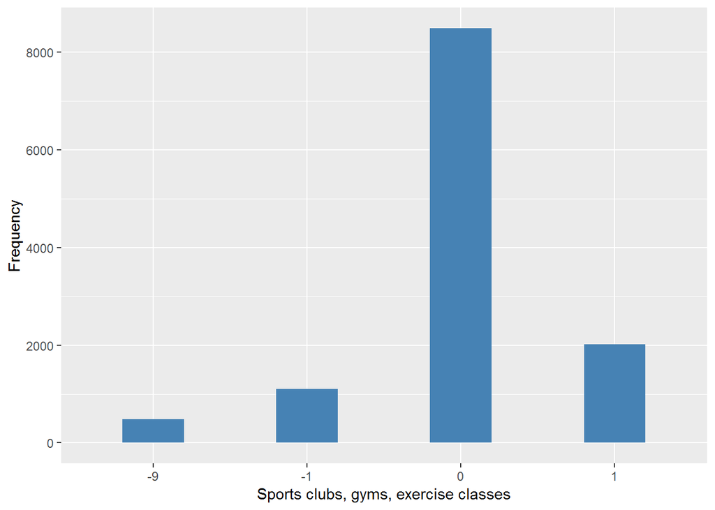

#### 2.1.1.2 Harmonisation algorithm

To compute the harmonize variable from the study-specific variable it has to be recoded as follows:

- `1 into 1, 0 into 0`
- `-1 into 996`
- `-9 into 995`
- `NA into 999`

**R script:**

```r
ELSA_ds_w1 <- tibble(id = ELSA_w1_sport$id)
ELSA_ds_w1$sport <- car::recode(as.vector(ELSA_w1_sport$scorg7), "0='0'; 1='1'; -1='996'; -9='995'; NA='999'")
ELSA_ds_w1$sport <- labelled(ELSA_ds_w1$sport, labels = c(No = 0, Yes = 1, Missing = 999,
    `Do not know` = 998, Refuse = 997, `Not applicable` = 996, `Don't answer` = 995,
    `Not attempt/not done/not yet recorded` = 994, `Disable to measure` = 993,
    Impute = 992, `CAPI/interviewer error` = 991))
```

#### 2.1.1.3 Statistical description of the new harmonised variable

Any participation currently in group sport activities (clubs, etc.)

| Sample size | Missing values |
| --- | --- |
| 12099 | 1593 |

Category

|  | 0 | 1 |
| --- | --- | --- |
| Frequency | 8491.00 | 2015.00 |
| Percentage | 70.18 | 16.65 |

Type of missing

|  | 991 | 992 | 993 | 994 | 995 | 996 | 997 | 998 | 999 | NA |
| --- | --- | --- | --- | --- | --- | --- | --- | --- | --- | --- |
| Frequency | 0 | 0 | 0 | 0 | 485.00 | 1108.00 | 0 | 0 | 0 | 0 |
| Percentage | 0 | 0 | 0 | 0 | 4.01 | 9.16 | 0 | 0 | 0 | 0 |

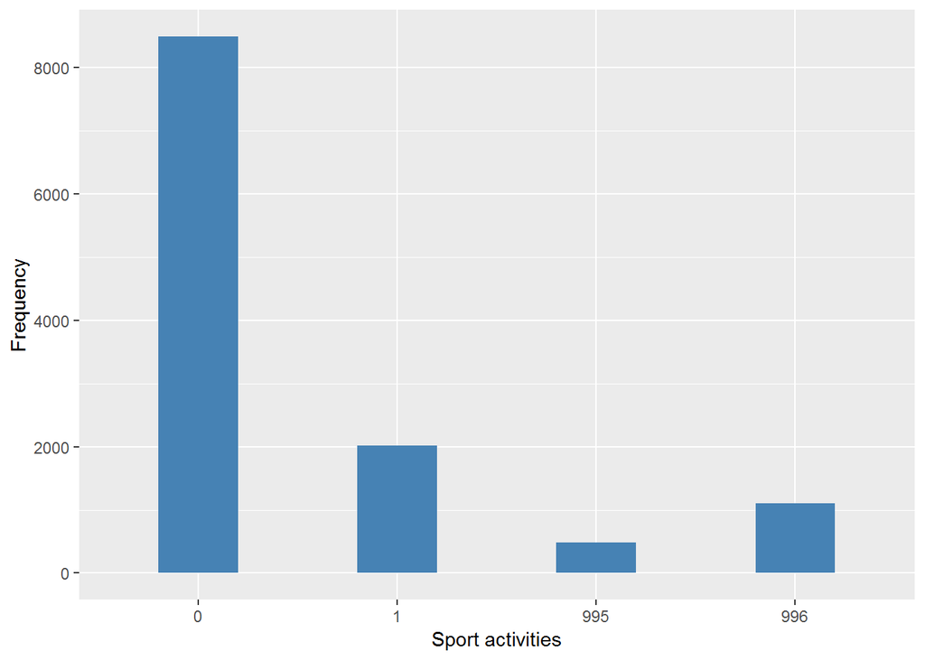

#### 2.1.1.4 Validation

|  | 0 | 1 | -9->995 | -1->996 |
| --- | --- | --- | --- | --- |
| BeforeH | 8491 | 2015 | 485 | 1108 |
| AfterH | 8491 | 2015 | 485 | 1108 |

### 2.1.2 Wave 2

#### 2.1.2.1 Study-specific variable description

| **Name** | `scorg07` |
| --- | --- |
| **Label** | `Organisational membership: member of a sports clubs, gym, or exercise class` |
| **Table name** | `wave_2_core_data_v4` |
| **Categories** | `0 = No` `1 = Yes` |
| **Missings** | `-9 = Not answered` `-1 = Item not applicable` |
| **Description** |  |

SCORG07

| Sample size | Missing values |
| --- | --- |
| 9432 | 1666 |

Category

|  | 0 | 1 |
| --- | --- | --- |
| Frequency | 6171.00 | 1595.00 |
| Percentage | 65.43 | 16.91 |

Type of missing

|  | -1 | -9 | NA |
| --- | --- | --- | --- |
| Frequency | 1072.00 | 594.0 | 0 |
| Percentage | 11.37 | 6.3 | 0 |

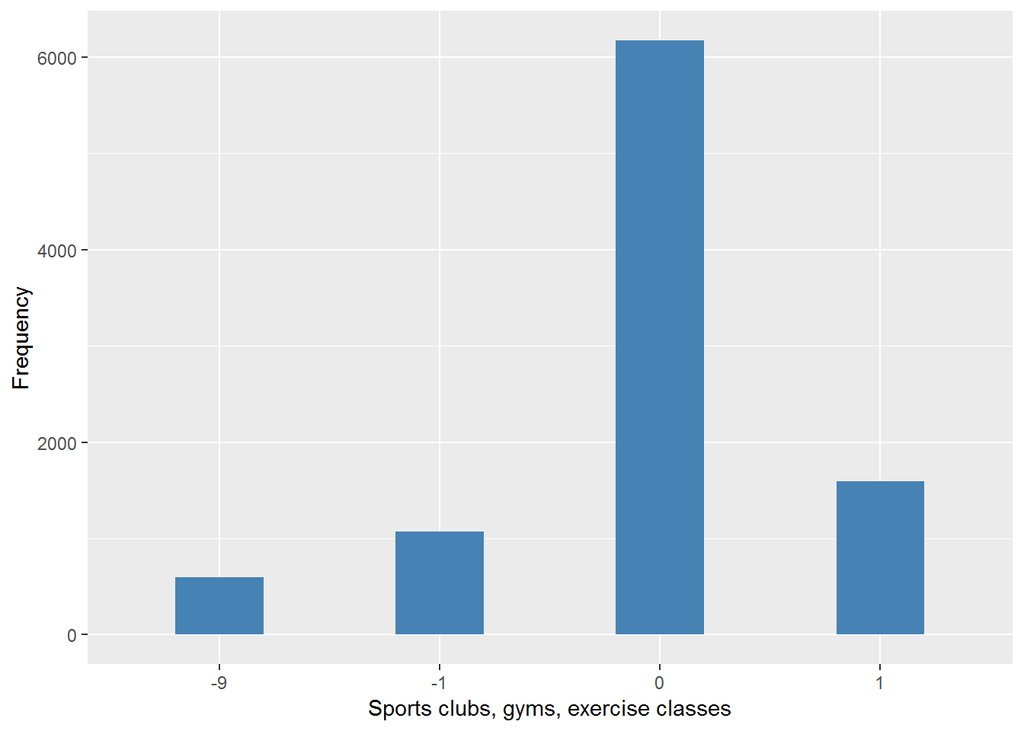

#### 2.1.2.2 Harmonisation algorithm

To compute the harmonize variable from the study-specific variable it has to be recoded as follows:

- `1 into 1, 0 into 0`
- `-1 into 996`
- `-9 into 995`
- `NA into 999`

**R script:**

```r
ELSA_ds_w2 <- tibble(id = ELSA_w2_sport$id)
ELSA_ds_w2$sport <- car::recode(as.vector(ELSA_w2_sport$scorg07), "0='0'; 1='1'; -1='996'; -9='995'; NA='999'")
ELSA_ds_w2$sport <- labelled(ELSA_ds_w2$sport, labels = c(No = 0, Yes = 1, Missing = 999,
    `Do not know` = 998, Refuse = 997, `Not applicable` = 996, `Don't answer` = 995,
    `Not attempt/not done/not yet recorded` = 994, `Disable to measure` = 993,
    Impute = 992, `CAPI/interviewer error` = 991))
```

#### 2.1.2.3 Statistical description of the new harmonised variable

Any participation currently in group sport activities (clubs, etc.)

| Sample size | Missing values |
| --- | --- |
| 9432 | 1666 |

Category

|  | 0 | 1 |
| --- | --- | --- |
| Frequency | 6171.00 | 1595.00 |
| Percentage | 65.43 | 16.91 |

Type of missing

|  | 991 | 992 | 993 | 994 | 995 | 996 | 997 | 998 | 999 | NA |
| --- | --- | --- | --- | --- | --- | --- | --- | --- | --- | --- |
| Frequency | 0 | 0 | 0 | 0 | 594.0 | 1072.00 | 0 | 0 | 0 | 0 |
| Percentage | 0 | 0 | 0 | 0 | 6.3 | 11.37 | 0 | 0 | 0 | 0 |

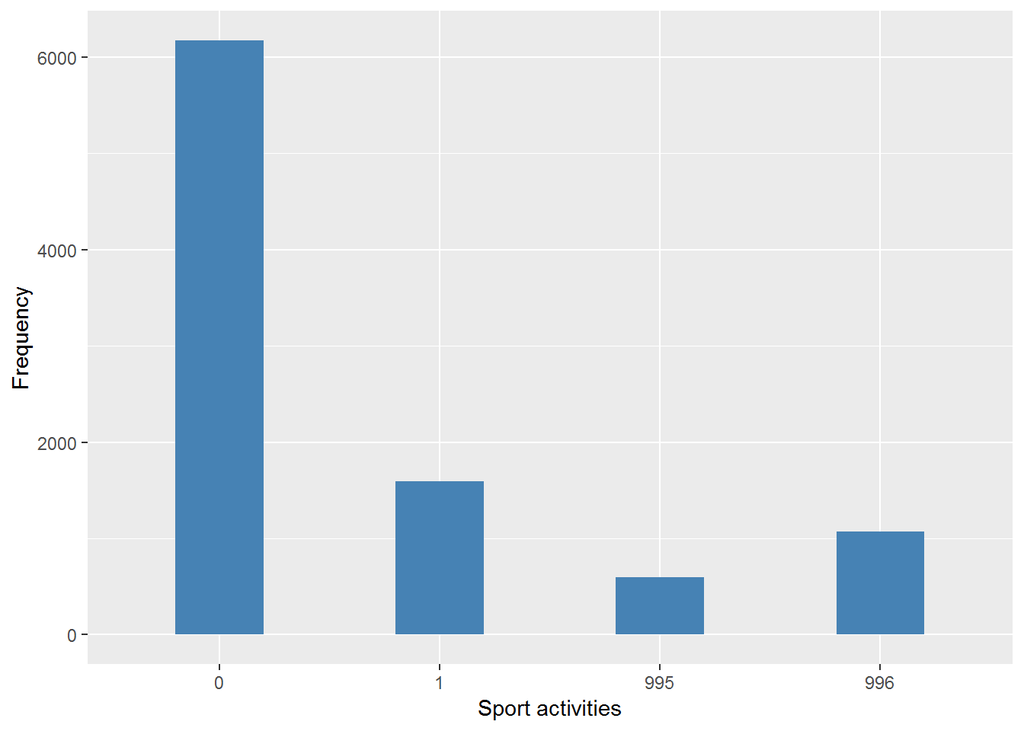

#### 2.1.2.4 Validation

|  | 0 | 1 | -9->995 | -1->996 |
| --- | --- | --- | --- | --- |
| BeforeH | 6171 | 1595 | 594 | 1072 |
| AfterH | 6171 | 1595 | 594 | 1072 |

### 2.1.3 Wave 3

#### 2.1.3.1 Study-specific variable description

| **Name** | `scorg07` |
| --- | --- |
| **Label** | `Respondent is a member of a sports clubs, gym, or exercise class` |
| **Table name** | `wave_3_elsa_data_v4` |
| **Categories** | `0 = No` `1 = Yes` |
| **Missings** | `-9 = Not answered` `-8 = Don't know` `-1 = Item not applicable` |
| **Description** |  |

SCORG07

| Sample size | Missing values |
| --- | --- |
| 9771 | 2006 |

Category

|  | 0 | 1 |
| --- | --- | --- |
| Frequency | 6074.00 | 1691.00 |
| Percentage | 62.16 | 17.31 |

Type of missing

|  | -1 | -8 | -9 | NA |
| --- | --- | --- | --- | --- |
| Frequency | 1527.00 | 0 | 479.0 | 0 |
| Percentage | 15.63 | 0 | 4.9 | 0 |

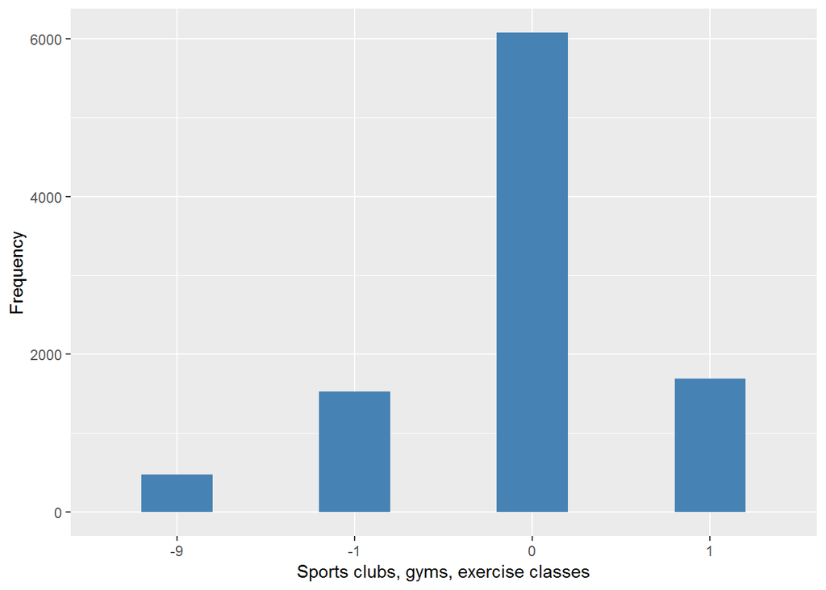

#### 2.1.3.2 Harmonisation algorithm

To compute the harmonize variable from the study-specific variable it has to be recoded as follows:

- `1 into 1, 0 into 0`
- `-1 into 996`
- `-8 into 998`
- `-9 into 995`
- `NA into 999`

**R script:**

```r
ELSA_ds_w3 <- tibble(id = ELSA_w3_sport$id)
ELSA_ds_w3$sport <- car::recode(as.vector(ELSA_w3_sport$scorg07), "0='0'; 1='1'; -1='996'; -8='998'; -9='995'; NA='999'")
ELSA_ds_w3$sport <- labelled(ELSA_ds_w3$sport, labels = c(No = 0, Yes = 1, Missing = 999,
    `Do not know` = 998, Refuse = 997, `Not applicable` = 996, `Don't answer` = 995,
    `Not attempt/not done/not yet recorded` = 994, `Disable to measure` = 993,
    Impute = 992, `CAPI/interviewer error` = 991))
```

#### 2.1.3.3 Statistical description of the new harmonised variable

Any participation currently in group sport activities (clubs, etc.)

| Sample size | Missing values |
| --- | --- |
| 9771 | 2006 |

Category

|  | 0 | 1 |
| --- | --- | --- |
| Frequency | 6074.00 | 1691.00 |
| Percentage | 62.16 | 17.31 |

Type of missing

|  | 991 | 992 | 993 | 994 | 995 | 996 | 997 | 998 | 999 | NA |
| --- | --- | --- | --- | --- | --- | --- | --- | --- | --- | --- |
| Frequency | 0 | 0 | 0 | 0 | 479.0 | 1527.00 | 0 | 0 | 0 | 0 |
| Percentage | 0 | 0 | 0 | 0 | 4.9 | 15.63 | 0 | 0 | 0 | 0 |

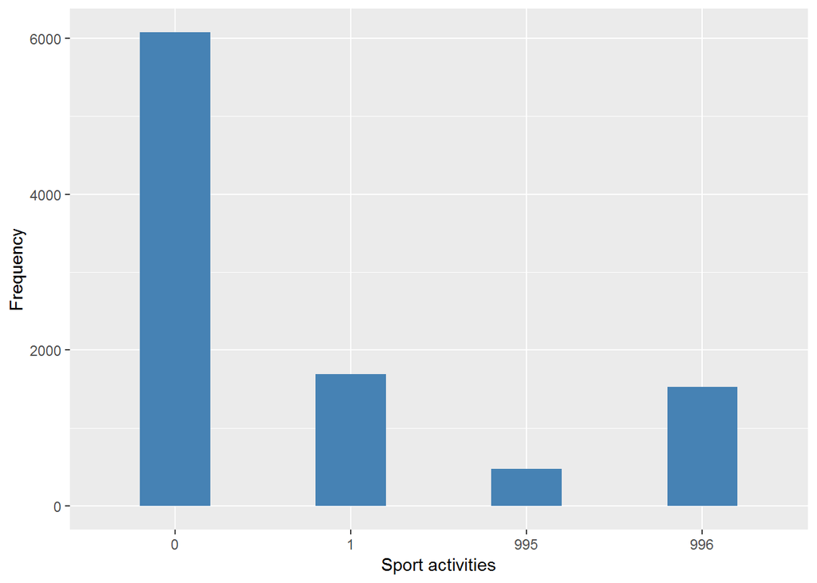

#### 2.1.3.4 Validation

|  | 0 | 1 | -9->995 | -1->996 |
| --- | --- | --- | --- | --- |
| BeforeH | 6074 | 1691 | 479 | 1527 |
| AfterH | 6074 | 1691 | 479 | 1527 |

### 2.1.4 Wave 4

#### 2.1.4.1 Study-specific variable description

| **Name** | `scorg07` |
| --- | --- |
| **Label** | `Respondent is a member of a sports clubs, gym, or exercise class` |
| **Table name** | `wave_4_elsa_data_v3` |
| **Categories** | `0 = No` `1 = Yes` |
| **Missings** | `-9 = Not answered` `-8 = Don't know` `-1 = Item not applicable` |
| **Description** |  |

SCORG07

| Sample size | Missing values |
| --- | --- |
| 11050 | 2170 |

Category

|  | 0 | 1 |
| --- | --- | --- |
| Frequency | 6818.0 | 2062.00 |
| Percentage | 61.7 | 18.66 |

Type of missing

|  | -1 | -8 | -9 | NA |
| --- | --- | --- | --- | --- |
| Frequency | 1708.00 | 0 | 462.00 | 0 |
| Percentage | 15.46 | 0 | 4.18 | 0 |

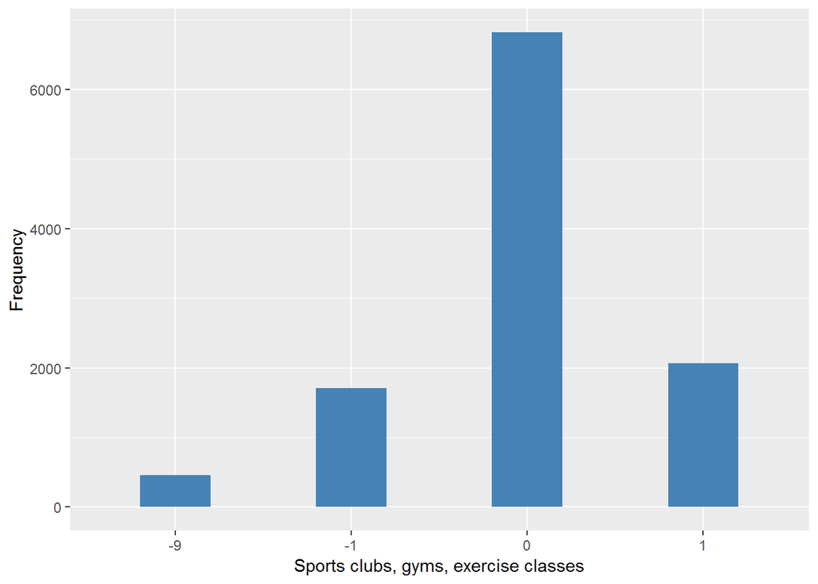

#### 2.1.4.2 Harmonisation algorithm

To compute the harmonize variable from the study-specific variable it has to be recoded as follows:

- `1 into 1, 0 into 0`
- `-1 into 996`
- `-8 into 998`
- `-9 into 995`
- `NA into 999`

**R script:**

```r
ELSA_ds_w4 <- tibble(id = ELSA_w4_sport$id)
ELSA_ds_w4$sport <- car::recode(as.vector(ELSA_w4_sport$scorg07), "0='0'; 1='1'; -1='996'; -8='998'; -9='995'; NA='999'")
ELSA_ds_w4$sport <- labelled(ELSA_ds_w4$sport, labels = c(No = 0, Yes = 1, Missing = 999,
    `Do not know` = 998, Refuse = 997, `Not applicable` = 996, `Don't answer` = 995,
    `Not attempt/not done/not yet recorded` = 994, `Disable to measure` = 993,
    Impute = 992, `CAPI/interviewer error` = 991))
```

#### 2.1.4.3 Statistical description of the new harmonised variable

Any participation currently in group sport activities (clubs, etc.)

| Sample size | Missing values |
| --- | --- |
| 11050 | 2170 |

Category

|  | 0 | 1 |
| --- | --- | --- |
| Frequency | 6818.0 | 2062.00 |
| Percentage | 61.7 | 18.66 |

Type of missing

|  | 991 | 992 | 993 | 994 | 995 | 996 | 997 | 998 | 999 | NA |
| --- | --- | --- | --- | --- | --- | --- | --- | --- | --- | --- |
| Frequency | 0 | 0 | 0 | 0 | 462.00 | 1708.00 | 0 | 0 | 0 | 0 |
| Percentage | 0 | 0 | 0 | 0 | 4.18 | 15.46 | 0 | 0 | 0 | 0 |

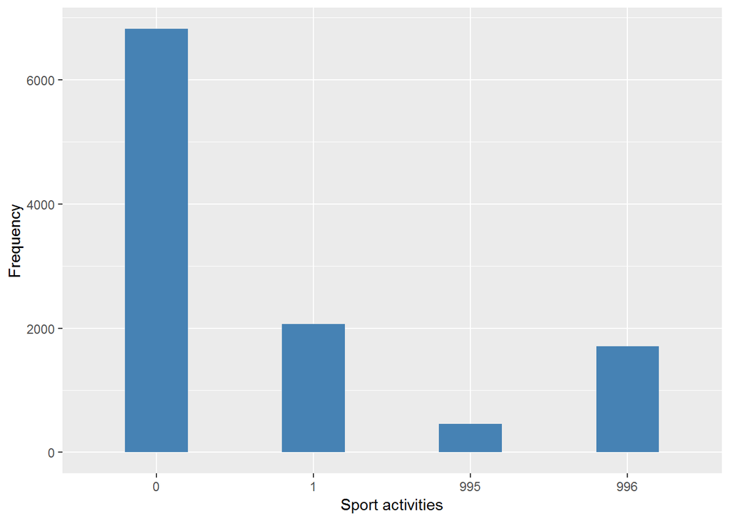

#### 2.1.4.4 Validation

|  | 0 | 1 | -9->995 | -1->996 |
| --- | --- | --- | --- | --- |
| BeforeH | 6818 | 2062 | 462 | 1708 |
| AfterH | 6818 | 2062 | 462 | 1708 |

### 2.1.5 Wave 5

#### 2.1.5.1 Study-specific variable description

| **Name** | `scorg07` |
| --- | --- |
| **Label** | `Respondent is a member of a sports clubs, gym, or exercise class` |
| **Table name** | `wave_5_elsa_data_v4` |
| **Categories** | `0 = No` `1 = Yes` |
| **Missings** | `-9 = Not answered` `-8 = Don't know` `-2 = Schedule Not Applicable` `-1 = Item not applicable` |
| **Description** |  |

SCORG07

| Sample size | Missing values |
| --- | --- |
| 10274 | 1729 |

Category

|  | 0 | 1 |
| --- | --- | --- |
| Frequency | 6536.00 | 2009.00 |
| Percentage | 63.62 | 19.55 |

Type of missing

|  | -1 | -2 | -8 | -9 | NA |
| --- | --- | --- | --- | --- | --- |
| Frequency | 0 | 1244.00 | 0 | 485.00 | 0 |
| Percentage | 0 | 12.11 | 0 | 4.72 | 0 |

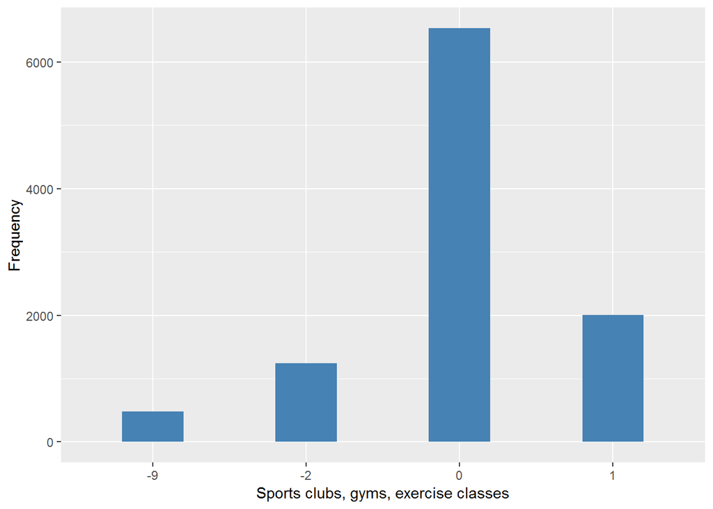

#### 2.1.5.2 Harmonisation algorithm

To compute the harmonize variable from the study-specific variable it has to be recoded as follows:

- `1 into 1, 0 into 0`
- `-1 or -2 into 996`
- `-8 into 998`
- `-9 into 995`
- `NA into 999`

**R script:**

```r
ELSA_ds_w5 <- tibble(id = ELSA_w5_sport$id)
ELSA_ds_w5$sport <- car::recode(as.vector(ELSA_w5_sport$scorg07), "0='0'; 1='1'; -1='996'; -2='996'; -8='998'; -9='995'; NA='999'")
ELSA_ds_w5$sport <- labelled(ELSA_ds_w5$sport, labels = c(No = 0, Yes = 1, Missing = 999,
    `Do not know` = 998, Refuse = 997, `Not applicable` = 996, `Don't answer` = 995,
    `Not attempt/not done/not yet recorded` = 994, `Disable to measure` = 993,
    Impute = 992, `CAPI/interviewer error` = 991))
```

#### 2.1.5.3 Statistical description of the new harmonised variable

Any participation currently in group sport activities (clubs, etc.)

| Sample size | Missing values |
| --- | --- |
| 10274 | 1729 |

Category

|  | 0 | 1 |
| --- | --- | --- |
| Frequency | 6536.00 | 2009.00 |
| Percentage | 63.62 | 19.55 |

Type of missing

|  | 991 | 992 | 993 | 994 | 995 | 996 | 997 | 998 | 999 | NA |
| --- | --- | --- | --- | --- | --- | --- | --- | --- | --- | --- |
| Frequency | 0 | 0 | 0 | 0 | 485.00 | 1244.00 | 0 | 0 | 0 | 0 |
| Percentage | 0 | 0 | 0 | 0 | 4.72 | 12.11 | 0 | 0 | 0 | 0 |

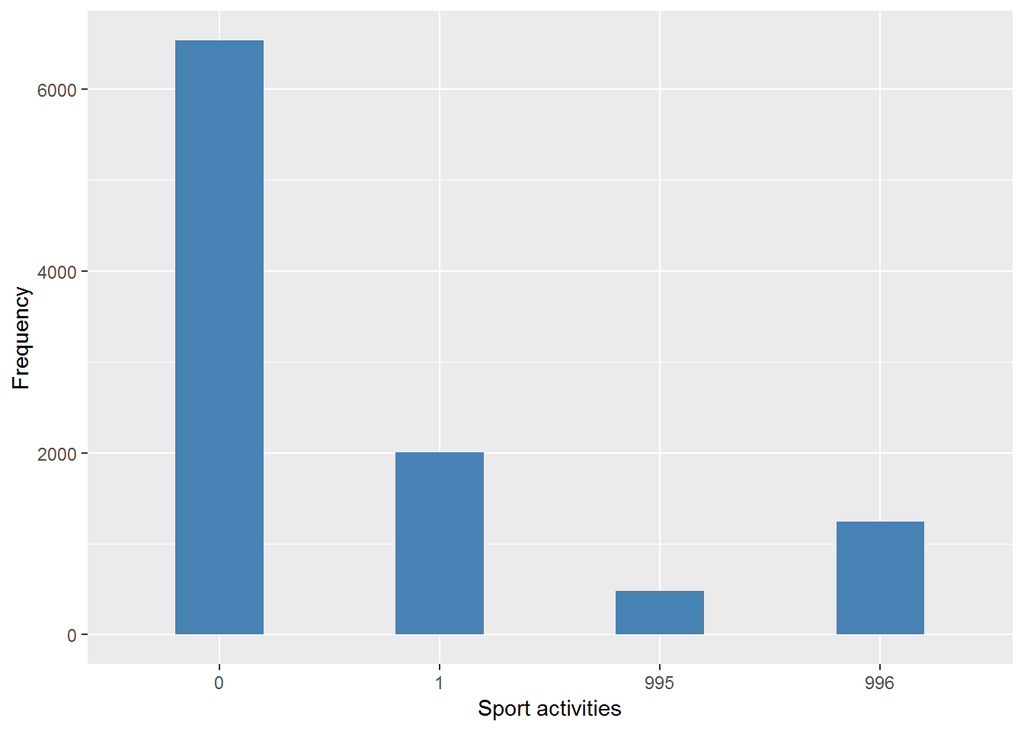

#### 2.1.5.4 Validation

|  | 0 | 1 | -9->995 | -2->996 |
| --- | --- | --- | --- | --- |
| BeforeH | 6536 | 2009 | 485 | 1244 |
| AfterH | 6536 | 2009 | 485 | 1244 |

### 2.1.6 Wave 6

#### 2.1.6.1 Study-specific variable description

| **Name** | `scorg07` |
| --- | --- |
| **Label** | `Respondent is a member of a sports clubs, gym, or exercise class` |
| **Table name** | `wave_6_elsa_data_v2` |
| **Categories** | `0 = No` `1 = Yes` |
| **Missings** | `-9 = Not answered` `-8 = Don't know` `-2 = Schedule Not Applicable` `-1 = Item not applicable` |
| **Description** |  |

SCORG07

| Sample size | Missing values |
| --- | --- |
| 10601 | 2026 |

Category

|  | 0 | 1 |
| --- | --- | --- |
| Frequency | 6479.00 | 2096.00 |
| Percentage | 61.12 | 19.77 |

Type of missing

|  | -1 | -2 | -8 | -9 | NA |
| --- | --- | --- | --- | --- | --- |
| Frequency | 0 | 1604.00 | 0 | 422.00 | 0 |
| Percentage | 0 | 15.13 | 0 | 3.98 | 0 |

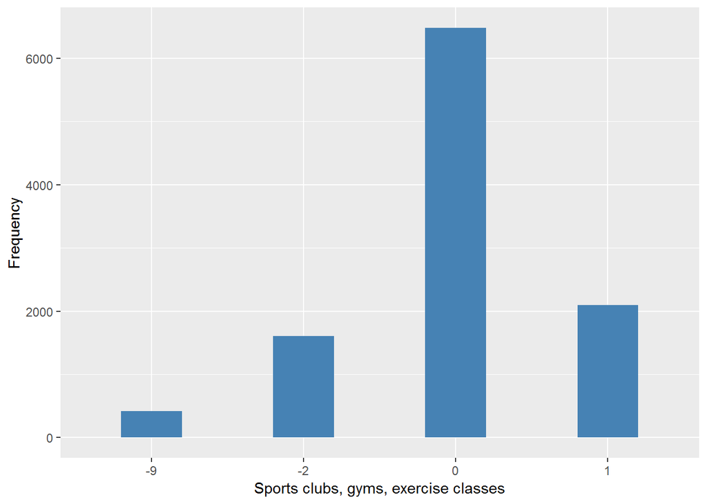

#### 2.1.6.2 Harmonisation algorithm

To compute the harmonize variable from the study-specific variable it has to be recoded as follows:

- `1 into 1, 0 into 0`
- `-1 or -2 into 996`
- `-8 into 998`
- `-9 into 995`
- `NA into 999`

**R script:**

```r
ELSA_ds_w6 <- tibble(id = ELSA_w6_sport$id)
ELSA_ds_w6$sport <- car::recode(as.vector(ELSA_w6_sport$scorg07), "0='0'; 1='1'; -1='996'; -2='996'; -8='998'; -9='995'; NA='999'")
ELSA_ds_w6$sport <- labelled(ELSA_ds_w6$sport, labels = c(No = 0, Yes = 1, Missing = 999,
    `Do not know` = 998, Refuse = 997, `Not applicable` = 996, `Don't answer` = 995,
    `Not attempt/not done/not yet recorded` = 994, `Disable to measure` = 993,
    Impute = 992, `CAPI/interviewer error` = 991))
```

#### 2.1.6.3 Statistical description of the new harmonised variable

Any participation currently in group sport activities (clubs, etc.)

| Sample size | Missing values |
| --- | --- |
| 10601 | 2026 |

Category

|  | 0 | 1 |
| --- | --- | --- |
| Frequency | 6479.00 | 2096.00 |
| Percentage | 61.12 | 19.77 |

Type of missing

|  | 991 | 992 | 993 | 994 | 995 | 996 | 997 | 998 | 999 | NA |
| --- | --- | --- | --- | --- | --- | --- | --- | --- | --- | --- |
| Frequency | 0 | 0 | 0 | 0 | 422.00 | 1604.00 | 0 | 0 | 0 | 0 |
| Percentage | 0 | 0 | 0 | 0 | 3.98 | 15.13 | 0 | 0 | 0 | 0 |

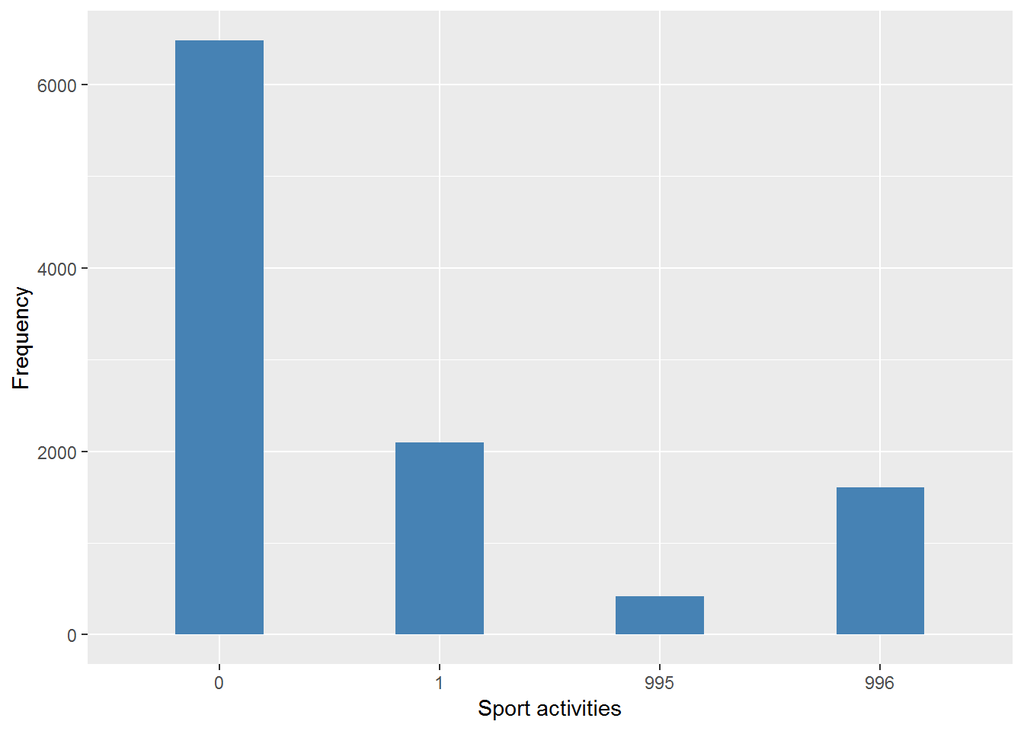

#### 2.1.6.4 Validation

|  | 0 | 1 | -9->995 | -2->996 |
| --- | --- | --- | --- | --- |
| BeforeH | 6479 | 2096 | 422 | 1604 |
| AfterH | 6479 | 2096 | 422 | 1604 |

### 2.1.7 Wave 7

#### 2.1.7.1 Study-specific variable description

| **Name** | `scorg07` |
| --- | --- |
| **Label** | `Respondent is a member of a sports clubs, gym, or exercise class` |
| **Table name** | `wave_7_elsa_data` |
| **Categories** | `0 = No` `1 = Yes` |
| **Missings** | `-9 = Not answered` `-8 = Don't know` `-2 = Schedule Not Applicable` `-1 = Item not applicable` |
| **Description** |  |

| Sample size | Missing values |
| --- | --- |
| 9666 | 1863 |

Category

|  | 0 | 1 |
| --- | --- | --- |
| Frequency | 5749.00 | 2054.00 |
| Percentage | 59.48 | 21.25 |

Type of missing

|  | -1 | -2 | -8 | -9 | NA |
| --- | --- | --- | --- | --- | --- |
| Frequency | 0 | 1469.0 | 0 | 394.00 | 0 |
| Percentage | 0 | 15.2 | 0 | 4.08 | 0 |

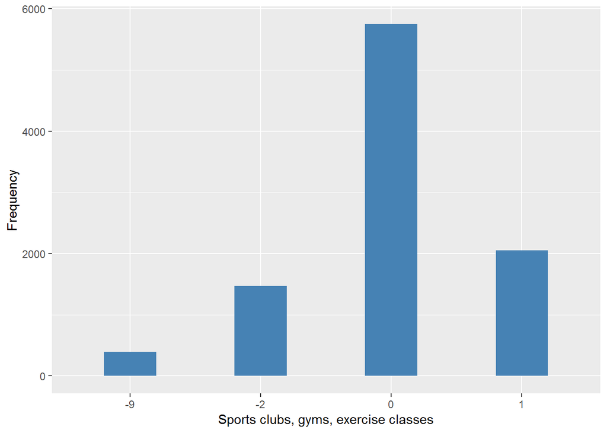

#### 2.1.7.2 Harmonisation algorithm

To compute the harmonize variable from the study-specific variable it has to be recoded as follows:

- `1 into 1, 0 into 0`
- `-1 or -2 into 996`
- `-8 into 998`
- `-9 into 995`
- `NA into 999`

**R script:**

```r
ELSA_ds_w7 <- tibble(id = ELSA_w7_sport$id)
ELSA_ds_w7$sport <- car::recode(as.vector(ELSA_w7_sport$scorg07), "0='0'; 1='1'; -1='996'; -2='996'; -8='998'; -9='995'; NA='999'")
ELSA_ds_w7$sport <- labelled(ELSA_ds_w7$sport, labels = c(No = 0, Yes = 1, Missing = 999,
    `Do not know` = 998, Refuse = 997, `Not applicable` = 996, `Don't answer` = 995,
    `Not attempt/not done/not yet recorded` = 994, `Disable to measure` = 993,
    Impute = 992, `CAPI/interviewer error` = 991))
```

#### 2.1.7.3 Statistical description of the new harmonised variable

Any participation currently in group sport activities (clubs, etc.)

| Sample size | Missing values |
| --- | --- |
| 9666 | 1863 |

Category

|  | 0 | 1 |
| --- | --- | --- |
| Frequency | 5749.00 | 2054.00 |
| Percentage | 59.48 | 21.25 |

Type of missing

|  | 991 | 992 | 993 | 994 | 995 | 996 | 997 | 998 | 999 | NA |
| --- | --- | --- | --- | --- | --- | --- | --- | --- | --- | --- |
| Frequency | 0 | 0 | 0 | 0 | 394.00 | 1469.0 | 0 | 0 | 0 | 0 |
| Percentage | 0 | 0 | 0 | 0 | 4.08 | 15.2 | 0 | 0 | 0 | 0 |

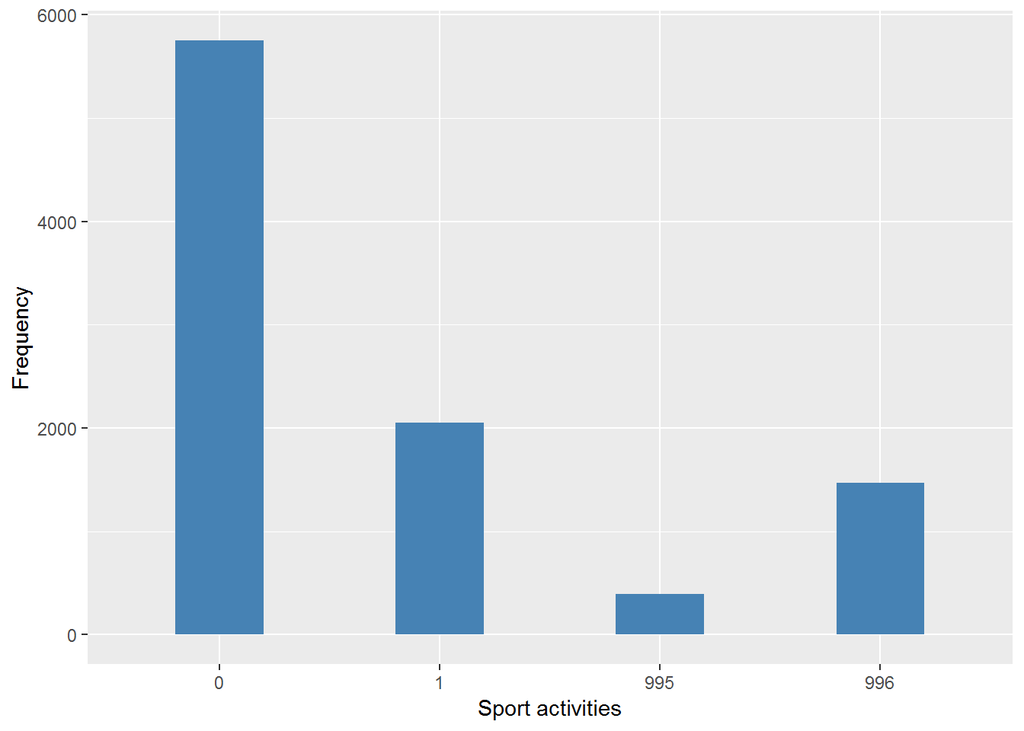

#### 2.1.7.4 Validation

|  | 0 | 1 | -9->995 | -2->996 |
| --- | --- | --- | --- | --- |
| BeforeH | 5749 | 2054 | 394 | 1469 |
| AfterH | 5749 | 2054 | 394 | 1469 |

## 2.2 Summary of descriptive statistics of the harmonised variable accross populations and waves

Two tables are generated:

1. Percentages of categories in each harmonised variable.
2. Frequencies and percentages of individuals with different trajectories. To avoid too large table, Only trajectories with percentages larger than 0.3 are shown.

Any participation currently in group sport activities (clubs, etc.)

| val | label | W1 | W2 | W3 | W4 | W5 | W6 | W7 |
| --- | --- | --- | --- | --- | --- | --- | --- | --- |
| 0 | No | 70.18 | 65.43 | 62.16 | 61.7 | 63.62 | 61.12 | 59.48 |
| 1 | Yes | 16.65 | 16.91 | 17.31 | 18.66 | 19.55 | 19.77 | 21.25 |
| 991 | CAPI interviewer error | 0 | 0 | 0 | 0 | 0 | 0 | 0 |
| 992 | Impute | 0 | 0 | 0 | 0 | 0 | 0 | 0 |
| 993 | Disable to measure | 0 | 0 | 0 | 0 | 0 | 0 | 0 |
| 994 | Not attempt not done | 0 | 0 | 0 | 0 | 0 | 0 | 0 |
| 995 | Does not answer | 4.01 | 6.3 | 4.9 | 4.18 | 4.72 | 3.98 | 4.08 |
| 996 | Not applicable | 9.16 | 11.37 | 15.63 | 15.46 | 12.11 | 15.13 | 15.2 |
| 997 | Refuse | 0 | 0 | 0 | 0 | 0 | 0 | 0 |
| 998 | Do not know | 0 | 0 | 0 | 0 | 0 | 0 | 0 |
| 999 | Missing | 0 | 0 | 0 | 0 | 0 | 0 | 0 |
| NA | NA | 0 | 0 | 0 | 0 | 0 | 0 | 0 |
| n | sample size | 12099 | 9432 | 9771 | 11050 | 10274 | 10601 | 9666 |

|  | val | frq | raw.prc |
| --- | --- | --- | --- |
| 1 | 0000000 | 1139 | 6.16 |
| 2 | 0000001 | 65 | 0.35 |
| 3 | 000000NA | 295 | 1.60 |
| 7 | 00000NA0 | 75 | 0.41 |
| 9 | 00000NANA | 247 | 1.34 |
| 18 | 0000NA00 | 74 | 0.40 |
| 26 | 0000NANANA | 278 | 1.50 |
| 47 | 000NA000 | 115 | 0.62 |
| 49 | 000NA00NA | 61 | 0.33 |
| 55 | 000NA0NANA | 59 | 0.32 |
| 67 | 000NANANANA | 512 | 2.77 |
| 117 | 00NA0000 | 115 | 0.62 |
| 136 | 00NA0NANANA | 73 | 0.39 |
| 168 | 00NANANANANA | 858 | 4.64 |
| 287 | 01NANANANANA | 67 | 0.36 |
| 288 | 0NA00000 | 113 | 0.61 |
| 305 | 0NA00NANANA | 57 | 0.31 |
| 326 | 0NA0NANANANA | 181 | 0.98 |
| 393 | 0NANANANANANA | 1882 | 10.18 |
| 394 | 1000000 | 93 | 0.50 |
| 506 | 10NANANANANA | 95 | 0.51 |
| 578 | 1111111 | 244 | 1.32 |
| 646 | 11NANANANANA | 86 | 0.47 |
| 730 | 1NANANANANANA | 253 | 1.37 |
| 731 | NA000000 | 59 | 0.32 |
| 797 | NA0NANANANANA | 149 | 0.81 |
| 840 | NANA00000 | 242 | 1.31 |
| 864 | NANA00NANANA | 64 | 0.35 |
| 909 | NANA0NANANANA | 217 | 1.17 |
| 945 | NANA11111 | 55 | 0.30 |
| 970 | NANA1NANANANA | 58 | 0.31 |
| 971 | NANANA0000 | 659 | 3.56 |
| 973 | NANANA000NA | 175 | 0.95 |
| 977 | NANANA00NA0 | 81 | 0.44 |
| 979 | NANANA00NANA | 165 | 0.89 |
| 989 | NANANA0NA00 | 78 | 0.42 |
| 991 | NANANA0NA0NA | 57 | 0.31 |
| 996 | NANANA0NANANA | 281 | 1.52 |
| 1010 | NANANA1111 | 182 | 0.98 |
| 1023 | NANANA1NANANA | 72 | 0.39 |
| 1024 | NANANANA000 | 122 | 0.66 |
| 1026 | NANANANA00NA | 74 | 0.40 |
| 1032 | NANANANA0NANA | 100 | 0.54 |
| 1042 | NANANANANA00 | 451 | 2.44 |
| 1044 | NANANANANA0NA | 224 | 1.21 |
| 1045 | NANANANANA10 | 77 | 0.42 |
| 1046 | NANANANANA11 | 133 | 0.72 |
| 1047 | NANANANANA1NA | 57 | 0.31 |
| 1048 | NANANANANANA0 | 378 | 2.04 |
| 1049 | NANANANANANA1 | 133 | 0.72 |
| 1050 | NANANANANANANA | 1753 | 9.48 |

# 3 Quality estimation